# Alpha diversity

The plot below is investigating the idea that treatment with the biocontrol strain K49 might reduce alpha diversity compared to treatment with the other fungal strains due to it potentially having a higher growth rate. In the 16S alpha diversity comparisons, the mix vs control, and mix vs K49 are the only statistically significant comparisons. (Only significant pairwise comparisons are labelled). There are no statistically significant differences in alpha diversity between the different fungal treatments in the ITS data.

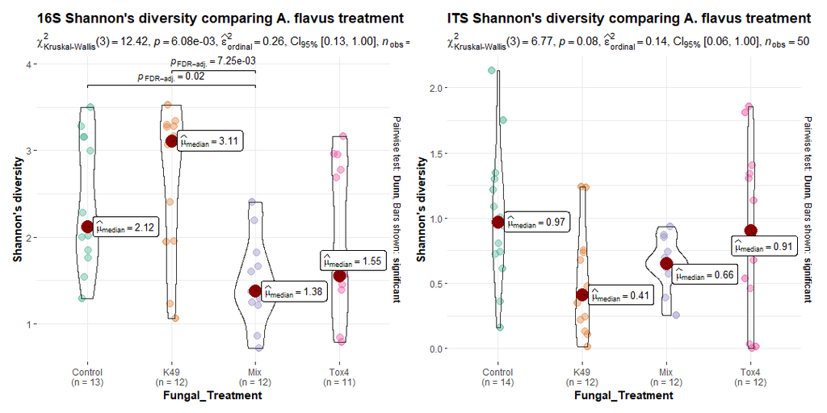

Repeated the above comparisons within each corn genotype. K49 has higher levels of Shannon’s diversity compared to Mix and Tox4 treated samples, but only within CML322 corn.

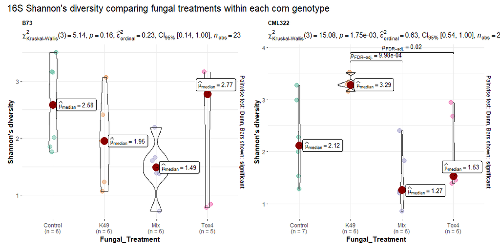

Still no differences at the ITS level.

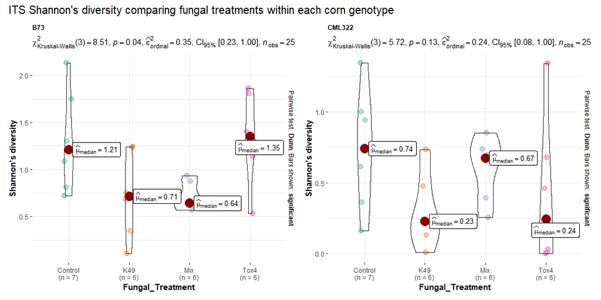

No differences in alpha diversity between corn lines for 16S data, but for the ITS data B73 is showing a higher diversity.

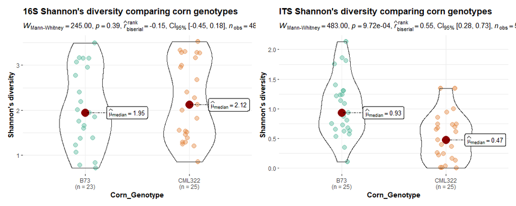

Repeated the above comparisons within each type of fungal treatment. For the 16S data, CML322 has higher levels of Shannon’s within K49 treated samples.

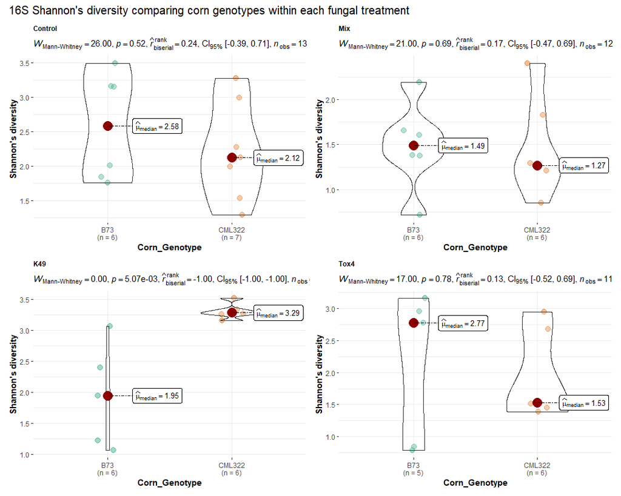

For the ITS data, B73 has higher levels of Shannon’s within Tox4 treated samples.

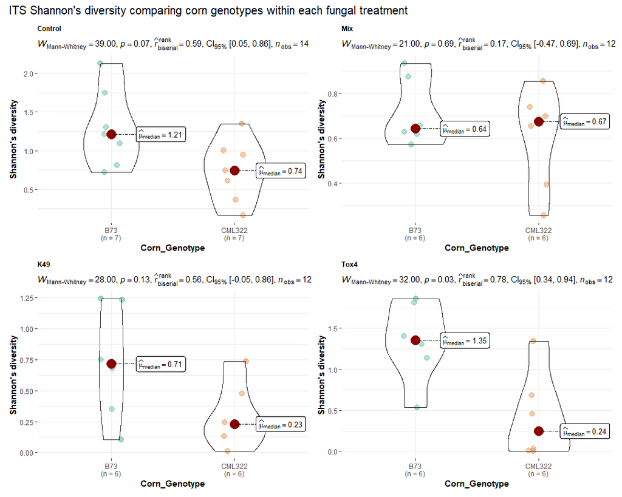

Also compared corn genotypes within each type of tissue extraction. For the 16S data, there are no differences between corn genotypes.

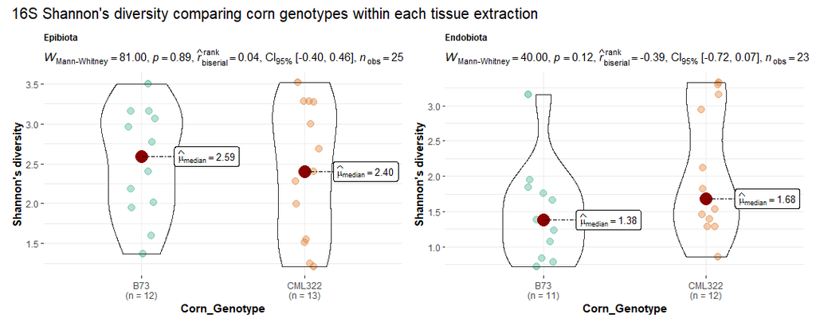

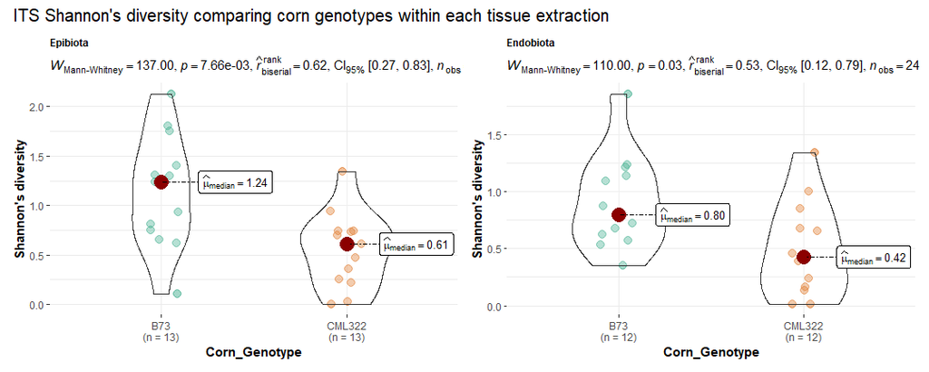

[output not shown]

Mock (control) samples have slightly higher diversity than flavus treated samples for the ITS data, however the 16S data shows no difference. This could be due to a large portion of the ITS sequencing in the flavus treated samples consisting of A. flavus sequences.

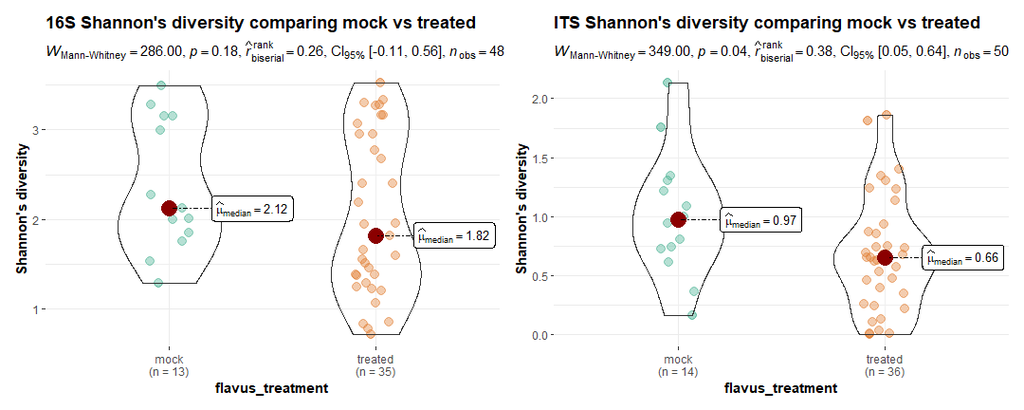

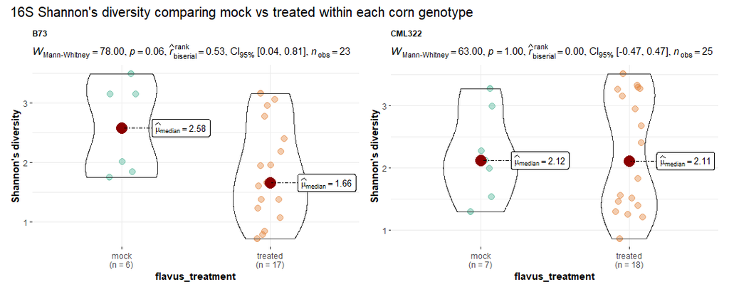

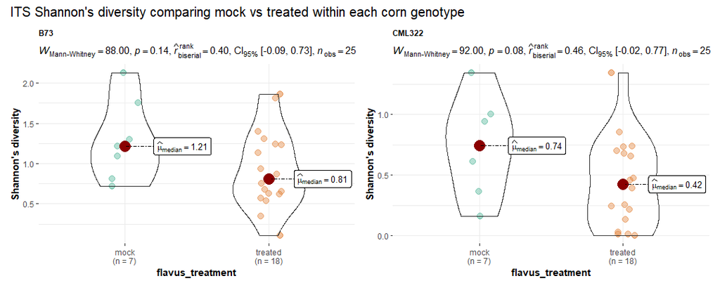

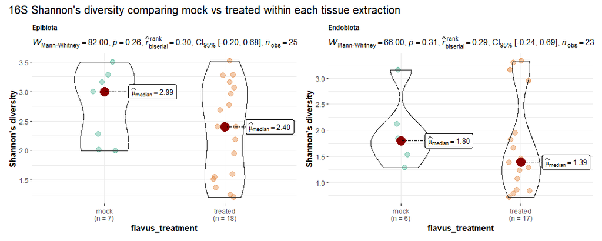

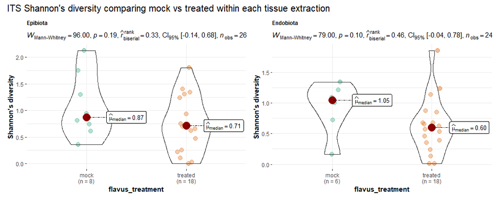